# Pizzería

Cueva Tomas

2023-02-12

# Análisis exploratorio; ventas de pizzeria.

Bienvenidos a este RMarkdown en donde analizaremos las ventas de una pizzería durante el periodo del año 2015, con el fin de encontrar aquellos productos más consumidos por los clientes y plantear reglas de asociación **con las pizzas más elegidas entre los clientes.**

## Inicialización de entorno

Prepararemos las librerías y funciones correspondientes.

### Instalación de librerías

```r
#install.packages("arules")
#install.packages("arulesViz")
#install.packages("dplyr")
#install.packages("lubridate")
#install.packages("ggplot2")
#install.packages("gridExtra")
#install.packages("stringr")
#install.packages("tidyverse")
#install.packages("readxl")
```

### Importación de librerias

```r
library(arules)
library(arulesViz)
library(dplyr)
library(lubridate)
library(ggplot2)
library(gridExtra)
library(stringr)
library(tidyverse)
library(DT)
library(readxl)
```

### Funciones utilizadas

```r
Apriori_algorithm <- function(rules,confidence_levels,transactions,support_levels,n){
  for (i in 1:length(confidenceLevels)) {
    rules[i] <- length(
      apriori(
        transactions,
        parameter = list(
          minlen = 1,
          sup = support_levels[n],
          conf = confidence_levels[i],
          target = "rules"
        )
      )
    )
  }

  return(rules)
}

numbers_rules <- function(confidence,rules,percentage,scale = NULL){
  if( ! is.null(scale)){
    plot <- qplot(
      confidence,
      rules,
      geom = c("point", "line"),
      xlab = "Confidence level", ylab = "Number of rules found",
      main = cat("Apriori with a support level of ",percentage)
    ) +
      scale_y_continuous(breaks = scale) +
      theme_bw()
  }else{
    plot <- qplot(
      confidence,
      rules,
      geom = c("point", "line"),
      xlab = "Confidence level", ylab = "Number of rules found",
      main = cat("Apriori with a support level of ",percentage)
    ) +
      theme_bw()
  }

  return(plot)
}

data_description <- function(data){
  na <- sum(is.na(data))
  if(na == 0){
    description <- "El dataframe no tiene valores na."
  }else{
    decription <- "El dataframe SI TIENE valores na."
    na.omit(data)
    print("se eliminarion "+ na + " valores NA")
  }

  description <-cat(description ,"\n", "Contiene " , nrow(data), " filas y ",ncol(data), " columnas","\n","Con las siguientes variables: ",names(data))

  return(description)
}
```

## Limpieza y descripción de datos

El dataset contiene datos y variables que para el propósito de este informe no son necesarios. Por lo que procederemos a importar y examinar el dataset para posteriormente hacer una debida manipulación de datos con el fin de tener un dataset más limpio.

### Lectura y descripción

```r
data <- read_xlsx("C:/Users/tomas/OneDrive/Escritorio/R/ProyectoFinal_R_CuevaTomas/data/PizzaSales.xlsx")

data_description(data)
```

```
## El dataframe no tiene valores na.
##  Contiene  48620  filas y  12  columnas
##  Con las siguientes variables:  order_details_id order_id pizza_id quantity order_date order_time unit_price total_price pizza_size pizza_category pizza_ingredients pizza_name
```

```r
glimpse(data)
```

```
## Rows: 48,620
## Columns: 12
## $ order_details_id  <dbl> 1, 2, 3, 4, 5, 6, 7, 8, 9, 10, 11, 12, 13, 14, 15, 1…
## $ order_id          <dbl> 1, 2, 2, 2, 2, 2, 3, 3, 4, 5, 6, 6, 7, 8, 9, 9, 9, 9…
## $ pizza_id          <chr> "hawaiian_m", "classic_dlx_m", "five_cheese_l", "ita…
## $ quantity          <dbl> 1, 1, 1, 1, 1, 1, 1, 1, 1, 1, 1, 1, 1, 1, 1, 1, 1, 1…
## $ order_date        <dttm> 2015-01-01, 2015-01-01, 2015-01-01, 2015-01-01, 201…
## $ order_time        <dttm> 1899-12-31 11:38:36, 1899-12-31 11:57:40, 1899-12-3…
## $ unit_price        <dbl> 13.25, 16.00, 18.50, 20.75, 16.00, 20.75, 16.50, 20.…
## $ total_price       <dbl> 13.25, 16.00, 18.50, 20.75, 16.00, 20.75, 16.50, 20.…
## $ pizza_size        <chr> "M", "M", "L", "L", "M", "L", "M", "L", "M", "M", "S…
## $ pizza_category    <chr> "Classic", "Classic", "Veggie", "Supreme", "Veggie",…
## $ pizza_ingredients <chr> "Sliced Ham, Pineapple, Mozzarella Cheese", "Peppero…
## $ pizza_name        <chr> "The Hawaiian Pizza", "The Classic Deluxe Pizza", "T…
```

### Limpieza y manipulación de datos

- **order_details_id, order_id y quantity:** Pasarán de ser datos tipo numeric/dbl a tipo integer para reducir la cantidad de memoria que ocupa el dataset.
- **pizza_id, order_time, pizza_size y pizza_ingredients:** Variables eliminadas ya que no son datos necesarios en nuestro caso.
- **pizza_category:** La volveremos de tipo factor.
- pizza_name: Al ser la variable más característica(ya que nos da un panorama de cuál es el menú de pizzas) la convertiremos en una variable de tipo factor.

```r
data_m <- data %>%
  mutate(
    order_details_id = as.integer(order_details_id),
    order_id = as.integer(order_id),
    quantity = as.integer(quantity),
    pizza_id = NULL,
    order_time = NULL,
    pizza_size = NULL,
    pizza_category = as.factor(pizza_category),
    pizza_name = str_sub(pizza_name,4,-6),
    pizza_name = as.factor(pizza_name),
    pizza_id = NULL,
    pizza_ingredients = NULL
  )
```

## Pizzas más vendidas

Haremos una suma de la cantidad de veces que se pidió cada pizza para obtener un ranking de las más pedidas por los clientes.

```r
best_pizzas <- data_m %>%
  select(
    pizza_name,quantity
  ) %>%
  group_by(
    pizza_name
  ) %>%
  summarise(sum(quantity)) %>%
  arrange(desc(`sum(quantity)`)) %>%
  transmute(
    pizza_name = factor(pizza_name,levels = pizza_name),
    Sales.quantity = `sum(quantity)`
  ) %>%
  mutate(
    X = 1:length(pizza_name)
  )

best_pizzas %>%
  slice(1:100) %>%
  DT::datatable(
    rownames = F,
    filter = "top"
  )
```

| pizza_name | Sales.quantity | X |
| --- | --- | --- |
| Classic Deluxe | 2453 | 1 |
| Barbecue Chicken | 2432 | 2 |
| Hawaiian | 2422 | 3 |
| Pepperoni | 2418 | 4 |
| Thai Chicken | 2371 | 5 |
| California Chicken | 2370 | 6 |
| Sicilian | 1938 | 7 |
| Spicy Italian | 1924 | 8 |
| Southwest Chicken | 1917 | 9 |
| Big Meat | 1914 | 10 |

[output cut: 22 more lines]

## Selección de pizzas

- Debido a la gran variedad de pizzas que posemos, vamos a hacer una selección de las 10 pizzas más pedidas por los clientes.

  ```r
  best_pizzas <- best_pizzas %>%
    filter(X < 11)

  select_pizzas <- data_m %>%
    mutate(
      pizza_name = as.factor(pizza_name)
    )%>%
    filter(
      pizza_name == best_pizzas$pizza_name[1] | pizza_name == best_pizzas$pizza_name[2] | pizza_name == best_pizzas$pizza_name[3] | pizza_name == best_pizzas$pizza_name[4] | pizza_name == best_pizzas$pizza_name[5] | pizza_name == best_pizzas$pizza_name[6] | pizza_name == best_pizzas$pizza_name[7] | pizza_name == best_pizzas$pizza_name[8] | pizza_name == best_pizzas$pizza_name[9] | pizza_name == best_pizzas$pizza_name[10]
    )
  ```

## Ventas por periodos

  No solo debemos tener en cuenta que pizzas son convenientes para realizar una buena estrategia de promoción, sino también el timing en el cual se va a ejecutar el plan. Esto lo examinaremos con la data de todas las ordenes del dataset inicial.

### Ventar por mes

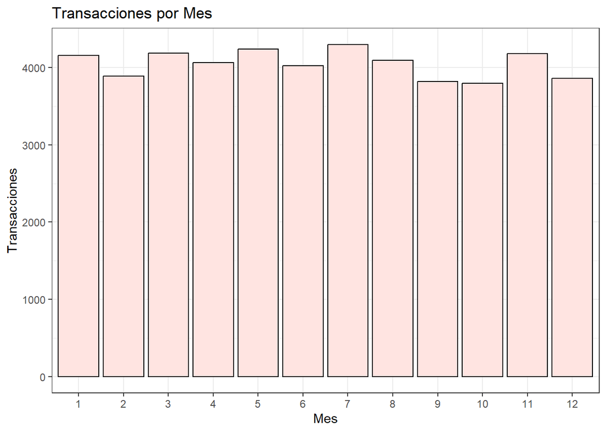

```r
data_m %>%
  mutate(
    Month = as.factor(month(order_date))
  ) %>%
  group_by(Month) %>%
  summarise(
    Transactions = n()
  ) %>%
  ggplot(aes(x = Month, y = Transactions))+
  geom_bar(stat = 'identity', fill = 'mistyrose1',show.legend = FALSE, color="black")+
  ylab("Transacciones")+
  xlab("Mes")+
  ggtitle("Transacciones por Mes")+
  theme_bw()
```

### Ventas por semana

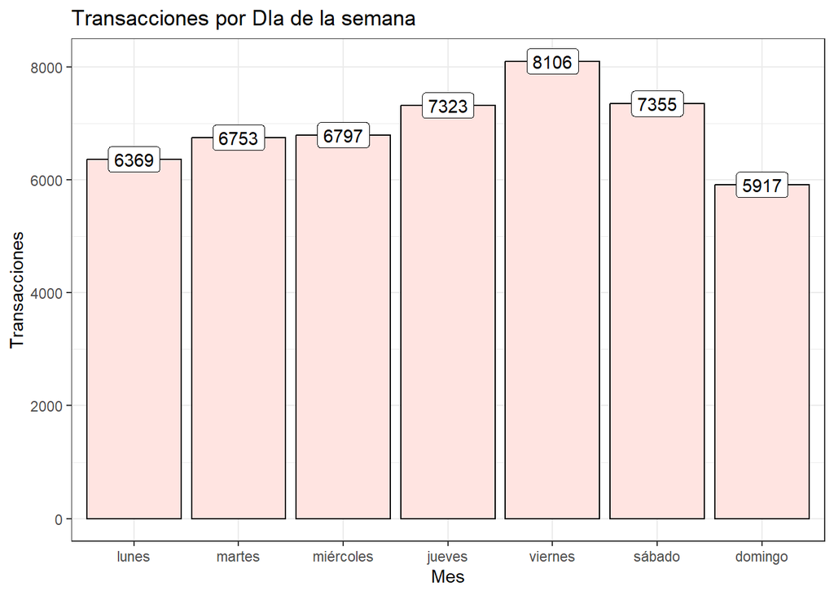

```r
data_m %>%
  mutate(
    DiaSemana = as.factor(weekdays(as.Date(order_date)))
  ) %>%
  group_by(DiaSemana) %>%
  summarise(
    Transactions = n()
  ) %>%
  ggplot(aes(x = DiaSemana, y = Transactions))+
  geom_bar(stat = "identity", fill = "mistyrose1", show.legend = FALSE, color = "black")+
  geom_label(aes(label = Transactions))+
  scale_x_discrete(
    limits = c("lunes","martes","miércoles","jueves","viernes","sábado","domingo")
  )+
  ylab("Transacciones")+
  xlab("Mes")+
  ggtitle("Transacciones por DIa de la semana")+
  theme_bw()
```

Como vemos, a nivel mensual no hay mucha diferenia en el nivel de ventas, sin embargo, si lo vemos semana a semana, podemos notar que los días viernes son aquellos en donde más flujo de clientes hay, por lo que este dato es interesante tenerlo en cuenta en el timing para lanzar las promociones.

## Basket market analisis

Hecho toda la transformacion y seleccion de la data, iniciaremos el analisis de reglas de asociación para examinar la organización de las posibles futuras promociones dentro de la pizzería.

### Transformación y exportación de la data

Transformaremos el dataset de las pizzas seleccionadas para realizar un dataframe el cual contenga por cada orden de compra unitaria, una lista de todas las pizzas pedidas en esa orden.

```r
data_orders <- select_pizzas %>%
  select(order_details_id,order_id,order_date,pizza_name) %>%
  group_by(order_id,order_date) %>%
  summarise(glue::glue_collapse(glue::glue("{pizza_name}"), sep = ','))

data_csv <- data_orders

data_csv$order_id <- NULL
data_csv$order_date <- NULL
data_csv$`glue::glue_collapse(glue::glue("{pizza_name}"), sep = ",")` <- as.character(data_csv$`glue::glue_collapse(glue::glue("{pizza_name}"), sep = ",")`)

write.csv(data_csv, "PizzasList.csv", quote = FALSE, row.names = TRUE)
```

### Lectura y limpieza de transacciones

Leemos nuestra lista de ordenes para obtener transacciones en formato Basket

```r
transacciones_pizzas <- read.transactions(
  "PizzasList.csv",
  rm.duplicates = TRUE,
  format = "basket",
  sep = ",",
  cols = 1
)
```

```
## distribution of transactions with duplicates:
## items
##   1   2   3   4
## 589  62  11   2
```

```r
transacciones_pizzas@itemInfo$labels <- gsub("\"","",transacciones_pizzas@itemInfo$labels)
```

### Frecuencias

Nos fijaremos la regularidad con la que los clientes compran cada pizza a partir de diferentes particularidades

#### Frecuencia absoluta

La frecuencia absoluta, es la cantidad total del ítem comprado, en un lapso de tiempo dado.

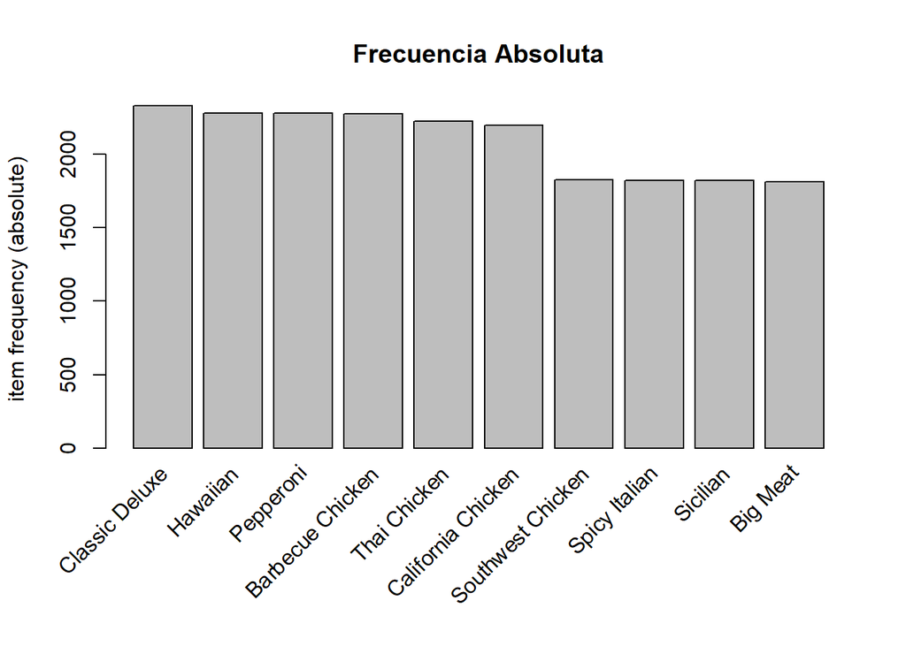

```r
itemFrequencyPlot(
  transacciones_pizzas,
  topN = 10,
  type = "absolute",
  main = "Frecuencia Absoluta"
)
```

#### Frecuencia relativa

La regularidad de compras del producto en relación al total de produtos comprados.

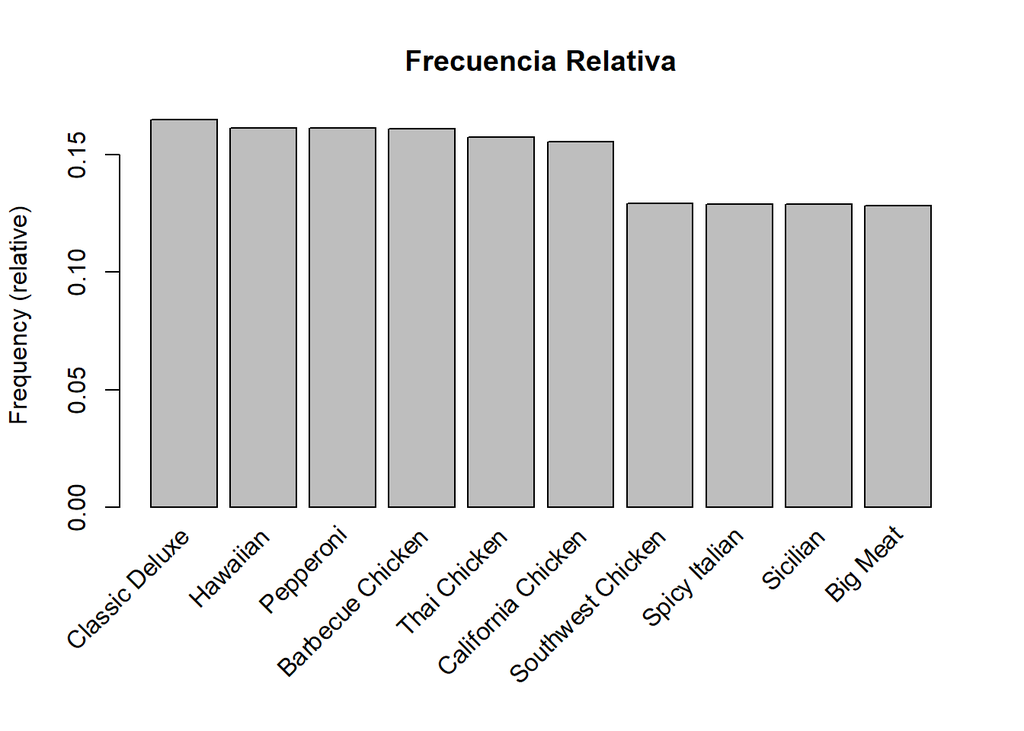

```r
itemFrequencyPlot(
  transacciones_pizzas,
  topN = 10,
  type = "relative",
  ylab = "Frequency (relative)",
  main="Frecuencia Relativa"
)
```

## Algoritmo Apriori

El algoritmo apriori va a ser aquel que nos va a buscar las reglas de asociación para nuestras transacciones

### Niveles de soporte y confianza

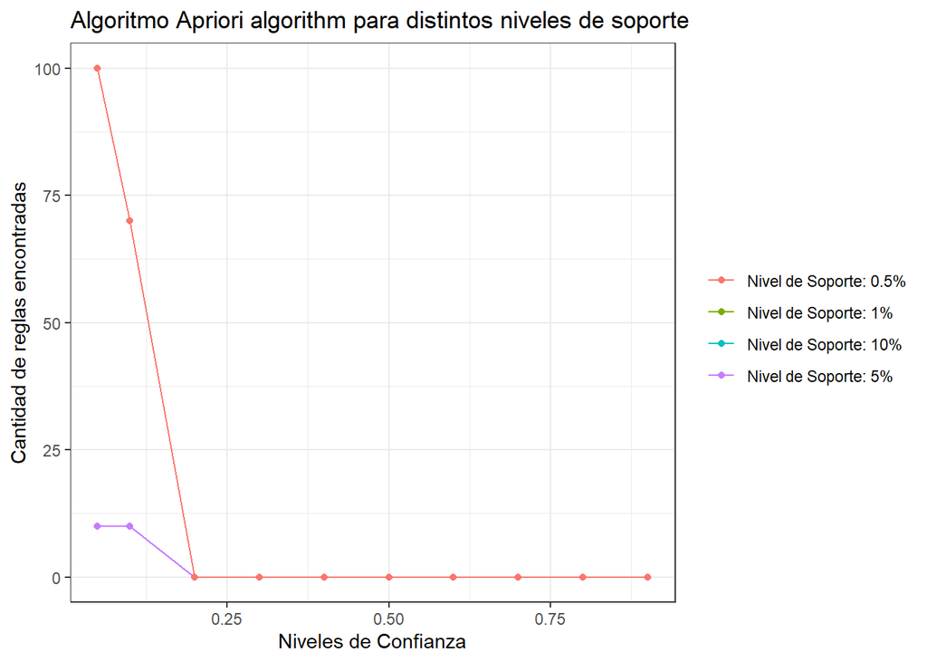

[output not shown]

|  | LHS | RHS | support | confidence | coverage | lift | count |
| --- | --- | --- | --- | --- | --- | --- | --- |
| [1] | {Big Meat,California Chicken,Spicy Italian} | {Thai Chicken} | 0.00113322473262979 | 0.444444444444444 | 0.00254975564841703 | 2.82027465667915 | 16 |
| [2] | {Big Meat,Spicy Italian,Thai Chicken} | {California Chicken} | 0.00113322473262979 | 0.372093023255814 | 0.00304554146894256 | 2.39125234198855 | 16 |
| [3] | {California Chicken,Spicy Italian,Thai Chicken} | {Big Meat} | 0.00113322473262979 | 0.41025641025641 | 0.00276223528578511 | 3.19845955627292 | 16 |
| [4] | {Big Meat,California Chicken,Thai Chicken} | {Spicy Italian} | 0.00113322473262979 | 0.390243902439024 | 0.00290388837736384 | 3.02406896736366 | 16 |
| [5] | {Big Meat,Spicy Italian,Thai Chicken} | {Classic Deluxe} | 0.00106239818684043 | 0.348837209302326 | 0.00304554146894256 | 2.11474133024454 | 15 |
| [6] | {Big Meat,Classic Deluxe,Spicy Italian} | {Thai Chicken} | 0.00106239818684043 | 0.394736842105263 | 0.00269140873999575 | 2.50484920165583 | 15 |
| [7] | {Classic Deluxe,Spicy Italian,Thai Chicken} | {Big Meat} | 0.00106239818684043 | 0.384615384615385 | 0.00276223528578511 | 2.99855583400586 | 15 |
| [8] | {Big Meat,Classic Deluxe,Thai Chicken} | {Spicy Italian} | 0.00106239818684043 | 0.340909090909091 | 0.00311636801473192 | 2.64176479393274 | 15 |
| [9] | {Sicilian,Spicy Italian,Thai Chicken} | {Hawaiian} | 0.00106239818684043 | 0.535714285714286 | 0.00198314328210213 | 3.31743421052632 | 15 |
| [10] | {Hawaiian,Sicilian,Spicy Italian} | {Thai Chicken} | 0.00106239818684043 | 0.416666666666667 | 0.00254975564841703 | 2.6440074906367 | 15 |

[output cut: 62 more lines]

Utilizando la tabla, vamos a acomodar la tabla de mayor a menor desde la variable “confidence” y seleccionamos aquellas relaciones con el nivel de confianza más alto y que supere el 50% de confianza.

```r
order <- c(rules_sup1_conf10[9],rules_sup1_conf10[22],rules_sup1_conf10[21])

inspectDT(order)
```

|  | LHS | RHS | support | confidence | coverage | lift | count |
| --- | --- | --- | --- | --- | --- | --- | --- |
| [9] | {Sicilian,Spicy Italian,Thai Chicken} | {Hawaiian} | 0.00106239818684043 | 0.535714285714286 | 0.00198314328210213 | 3.31743421052632 | 15 |
| [22] | {Big Meat,Classic Deluxe,Southwest Chicken} | {Sicilian} | 0.00127487782420851 | 0.529411764705882 | 0.0024081025568383 | 4.10701357466063 | 18 |
| [21] | {Big Meat,Sicilian,Southwest Chicken} | {Classic Deluxe} | 0.00127487782420851 | 0.514285714285714 | 0.00247892910262766 | 3.11773293258909 | 18 |

### Gráficos de asociaciónes

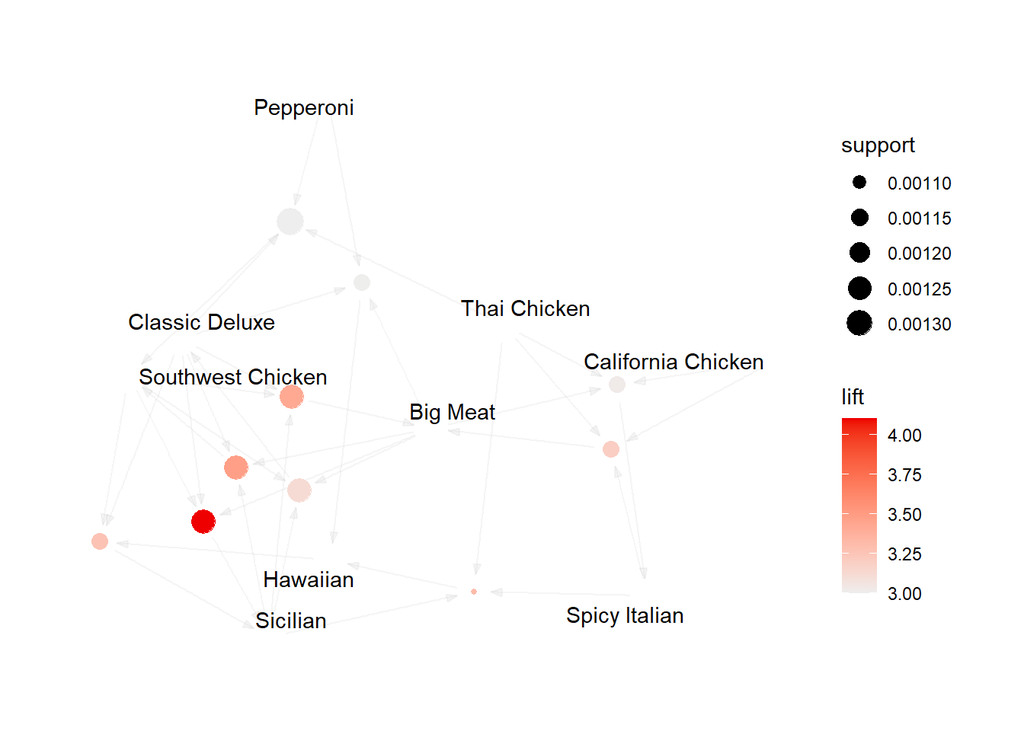

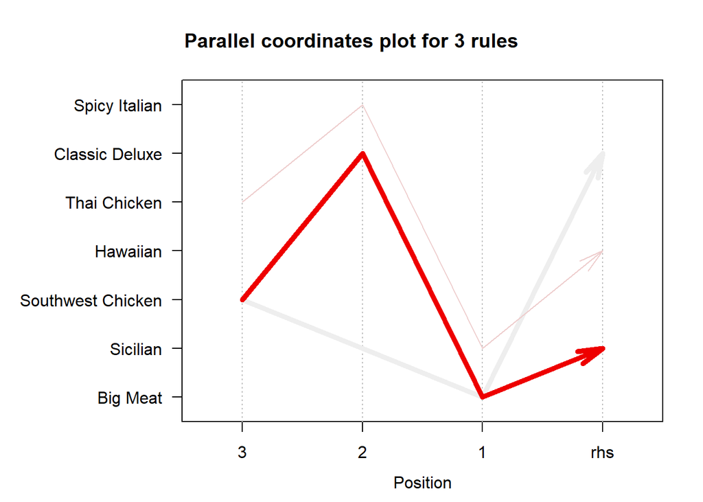

#### Interpretación

Tener en cuenta que a la hora de desarrollar una estrategia de promoción y/o recomendación, tambien debemos prestarle atención al timing, ya que no tendran el mismo nivel de impacto los diías viernes, en donde son los días con más flujo de clientes, que los domingos los cuales son los días donde menos ventas se dán.